# Projet : Analyse de Survie

```r
knitr::opts_chunk$set(
    echo = TRUE,
    message = FALSE,
    warning = FALSE)
```

## Cancer du poumon

### Description des données et significations des termes techniques :

**inst** : Code de l’institution

**time** : Durée de survie en jours

**status** : statut de censure 1=censuré, 2=mort

**age** : Âge en années

**sexe** : Male=1 Female=2

**ph.ecog** : Score de performance ECOG tel qu’évalué par le médecin. 0=asymptomatique, 1= symptomatique mais complètement ambulatoire, 2= au lit <50% de la journée, 3= au lit > 50% de la journée mais pas alité, 4= alité.

```
0 : Aucune limitation, état fonctionnel identique à celui pré-morbide

1 : Restriction aux activités physiques, mais ambulant et capable d'effectuer des travaux légers ou sédentaires (ex: travaux ménagers, travail de bureau)

2 : Ambulant et capable de prendre soin de sa personne mais incapable de travailler; actif pour plus de 50% de la journée

3 : Capacité très limitée de prendre soin de sa personne; confiné au lit ou au fauteuil pour plus de 50% de la journée

4 : Incapacité totale; ne peut prendre soin de sa personne; confiné au fauteuil ou au lit

5 : Mort
```

**ph.karno** : Score de performance de Karnofsky (mauvais=0-bon=100) évalué par le médecin.

**pat.karno** : Score de performance de Karnofsky évalué par le patient

```
100 :   Normal ; aucune plainte, aucun signe de maladie.

90 :    En mesure de poursuivre une activité normale ; signes ou symptômes mineurs de maladie.

80 :    Activité normale, avec un effort ; quelques signes ou symptômes de maladie.

70 :    Autonome ; incapable de poursuivre une activité normale ou de travailler de façon active.

60 :    Nécessité occasionnelle d'assistance mais capacité de pourvoir à ses besoins essentiels.

50 :    Nécessité d'aide considérable à la personne, soins médicaux fréquents.

40 :    Invalide ; nécessité de soins et d'assistance spécifiques.

30 :    Complètement invalide ; indication d'hospitalisation, pas de risque imminent de décès.

20 :    Très malade ; hospitalisation nécessaire, traitement actif ou de support nécessaire.

10 :    Moribond ; issue fatale proche.

0 : Décédé.
```

**meal.cal** : Calories consommées lors des repas

**wt.loss** : Perte de poids au cours des six derniers mois

### Importation des données

```r
library(survival)

data('cancer')

head(cancer, 10)
```

```
##    inst time status age sex ph.ecog ph.karno pat.karno meal.cal wt.loss
## 1     3  306      2  74   1       1       90       100     1175      NA
## 2     3  455      2  68   1       0       90        90     1225      15
## 3     3 1010      1  56   1       0       90        90       NA      15
## 4     5  210      2  57   1       1       90        60     1150      11
## 5     1  883      2  60   1       0      100        90       NA       0
## 6    12 1022      1  74   1       1       50        80      513       0
## 7     7  310      2  68   2       2       70        60      384      10
## 8    11  361      2  71   2       2       60        80      538       1
## 9     1  218      2  53   1       1       70        80      825      16
## 10    7  166      2  61   1       2       70        70      271      34
```

```r
attach(cancer)
```

### Graphiques des variables d’études:

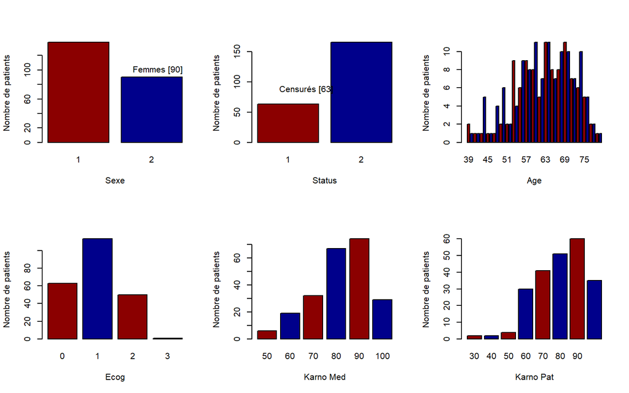

```r
par(mfrow=c(2,3))

barplot(table(sex), xlab = "Sexe",
        ylab = "Nombre de patients",
        col = c("darkred", "darkblue"))
text(x = c(140, 90), c("Hommes [138]","Femmes [90]"),
     adj = .5, pos = 3, offset = 0.5)
barplot(table(status), xlab = "Status",
        ylab = "Nombre de patients",
        col = c("darkred", "darkblue"))
text(x = c(80, 185), c("Censurés [63]","Morts [165]"),
     adj = .1, pos = 3, offset = 0.2)
barplot(table(age), xlab = "Age",
        ylab = "Nombre de patients",
        col = c("darkred", "darkblue"))
barplot(table(ph.ecog), xlab = "Ecog",
        ylab = "Nombre de patients",
        col = c("darkred", "darkblue"))
barplot(table(ph.karno), xlab = "Karno Med",
        ylab = "Nombre de patients",
        col = c("darkred", "darkblue"))
barplot(table(pat.karno), xlab = "Karno Pat",
        ylab = "Nombre de patients",
        col = c("darkred", "darkblue"))
```

Parmi les 228 patients, on a 138 hommes et 90 femmes qui ont participés

```r
summary(cancer)
```

```
##       inst            time            status           age
##  Min.   : 1.00   Min.   :   5.0   Min.   :1.000   Min.   :39.00
##  1st Qu.: 3.00   1st Qu.: 166.8   1st Qu.:1.000   1st Qu.:56.00
##  Median :11.00   Median : 255.5   Median :2.000   Median :63.00
##  Mean   :11.09   Mean   : 305.2   Mean   :1.724   Mean   :62.45
##  3rd Qu.:16.00   3rd Qu.: 396.5   3rd Qu.:2.000   3rd Qu.:69.00
##  Max.   :33.00   Max.   :1022.0   Max.   :2.000   Max.   :82.00
##  NA's   :1
##       sex           ph.ecog          ph.karno        pat.karno
##  Min.   :1.000   Min.   :0.0000   Min.   : 50.00   Min.   : 30.00
##  1st Qu.:1.000   1st Qu.:0.0000   1st Qu.: 75.00   1st Qu.: 70.00
##  Median :1.000   Median :1.0000   Median : 80.00   Median : 80.00
##  Mean   :1.395   Mean   :0.9515   Mean   : 81.94   Mean   : 79.96
##  3rd Qu.:2.000   3rd Qu.:1.0000   3rd Qu.: 90.00   3rd Qu.: 90.00
##  Max.   :2.000   Max.   :3.0000   Max.   :100.00   Max.   :100.00
##                  NA's   :1        NA's   :1        NA's   :3
##     meal.cal         wt.loss
##  Min.   :  96.0   Min.   :-24.000
##  1st Qu.: 635.0   1st Qu.:  0.000
##  Median : 975.0   Median :  7.000
##  Mean   : 928.8   Mean   :  9.832
##  3rd Qu.:1150.0   3rd Qu.: 15.750
##  Max.   :2600.0   Max.   : 68.000
##  NA's   :47       NA's   :14
```

### Objectif

Notre jeu de données contient des informations (age, genre, scores de performance) recueillies en jour sur 228 patients atteintent d’un cancer de poumon.

Notre objectif est à partir de ces informations, connaître le temps de survie générale (l’évolution de la maladie), puis voir si d’autres facteurs (covariables) telsque le genre, l’âge, ou les mesures de performances enrégistrées sur ces patients n’ont pas d’influences sur la durée de survie.

Pour répondre à ces questions, nous allons suivre un plan academique (TP) qui nous a été donné, en partant de la mise en place des modèles simples (estimation de la fonction de survie, taux d’incidences, …) dans le cas non parametrique et parametrique jusqu’à la comparaison des courbes de survie avec des tests (logrank, modèle de Cox).

Au fuir à mésure qu’on fera les analyses, l’objectif est succeptible d’évoluer car c’est notre première expérience avec ce type d’analyse de données.

### Organisation de nos données

Nous allons ajouter une nouvelle colonne dans notre jeu de données qui s’appelle «mort». Il stocke les données indiquant si une personne faisant partie de notre expérience est morte ou vivante (en fonction de la valeur de **statut**). Dans cette nouvelle variable, le signe **+** indique le status **survivant**.

```r
cancer2 <- cancer

cancer2$mort <- with(cancer2, Surv(time, status == 2))

head(cancer2)
```

```
##   inst time status age sex ph.ecog ph.karno pat.karno meal.cal wt.loss  mort
## 1    3  306      2  74   1       1       90       100     1175      NA   306
## 2    3  455      2  68   1       0       90        90     1225      15   455
## 3    3 1010      1  56   1       0       90        90       NA      15 1010+
## 4    5  210      2  57   1       1       90        60     1150      11   210
## 5    1  883      2  60   1       0      100        90       NA       0   883
## 6   12 1022      1  74   1       1       50        80      513       0 1022+
```

## Estimation du modèle sans covariables

Ici, l’objectif est de trouver le nombre de jours pendant lesquels un patient a survécu avant de mourir. Notre événement d’intérêt sera «la mort», qui est stockée dans la colonne «mort». Le premier argument qu’il prend est la chronologie de notre expérience.

Les données censurées sont marquées par +. Elles ne sont pas prise en charge lors des études suivantes

```r
kpl_one <- survfit(mort ~ 1, data = cancer2, conf.type = "log-log")

#summary(kpl_one)

#summary(kpl_one)
library(survminer)
```

## Visualisation de la courbe de survie

### Estimateur Kaplan-Meier

**NB**: En abscence des données de censure (censurés), Kaplan-Meier ~ Survie

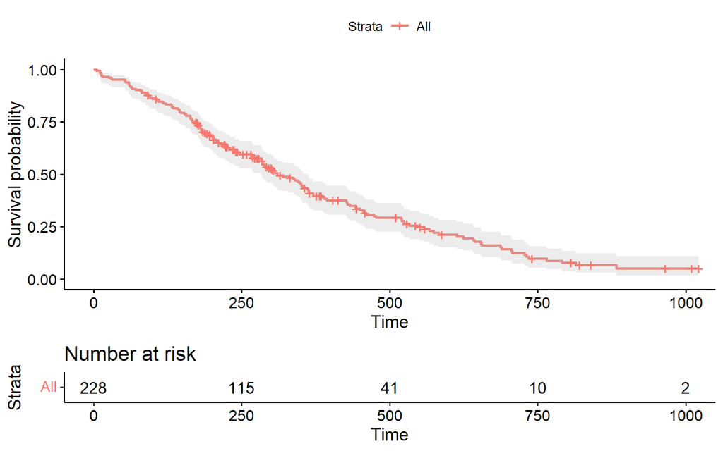

```r
# hist(kpl_one$surv, col = kpl_one$time,
#      main = paste("Histogrammme du Kaplan-Meier"), ylim = NULL,
#      xlab = "Survie", ylab="Nombre de Patients", angle = 100)


library(survminer)

ggsurvplot(kpl_one, data=cancer2, conf.int = TRUE, risk.table = TRUE, pval = TRUE)
```

### Estimateur Nelson-Aalen et Breslow

```r
# Calcul manuelle

myNelsonAalen <- function(survit_value, titre= "Courbe de Nelson-Aalen", legendes= c("Morts"), covariable= FALSE, graph= TRUE){
  if(!covariable){

    n <- survit_value$n
    temps <- survit_value$time
    risq_cum <- cumsum(survit_value$n.event/survit_value$n.risk)

    if(graph){

      plot(c(0,temps),c(0, risq_cum), type="s" ,col="red" ,
           xlab="Temps depuis dernière rechute",
           ylab="Risque cumulé", main=titre)
      legend("topleft",legendes,col=2,lty=c(1,1),
             cex=1.6,inset = 0.05 )
    }

    #Risk_cumule <- list(Risk_cum= risq_cum)
    #return(Risk_cumule)
  }


  if(covariable){
    result <- survit_value
    n1<-result$strata[1]; n2<-result$strata[2]
    temps1 <- result$time[1:n1]
    temps2 <- result$time[(n1+1):(n1+n2)]

    risq_cum1 <- cumsum(result$n.event[1:n1]/result$n.risk[1:n1])
    risq_cum2 <- cumsum(result$n.event[(n1+1):(n1+n2)]/
                   result$n.risk[(n1+1):(n1+n2)])
    if(graph){
    plot(c(0,temps2,1000),c(0,risq_cum2, risq_cum2[(n2)]), type="s",
         col="red", xlim=c(0,1000), xlab="Temps depuis dernière rechute",
         ylab="Risque cumulé", main=titre)
    lines(c(0,temps1), c(0,risq_cum1), type="s")
    legend("topleft", legendes, col=c(1,2),lty=c(1,1),
           cex=1.2,inset = 0.05 )
    }

    Risk_cumule <- list(Risk_cum1= risq_cum1, Risk_cum2= risq_cum2)
    #return(Risk_cumule)
  }
}

eBreslow = -log(kpl_one$surv)

#eBreslow

n1 <- kpl_one$n

xval <- kpl_one$time
n1 <- kpl_one$n

xval <- kpl_one$time
#yval <- cumsum(kpl_one$n.event/kpl_one$n.risk)
```

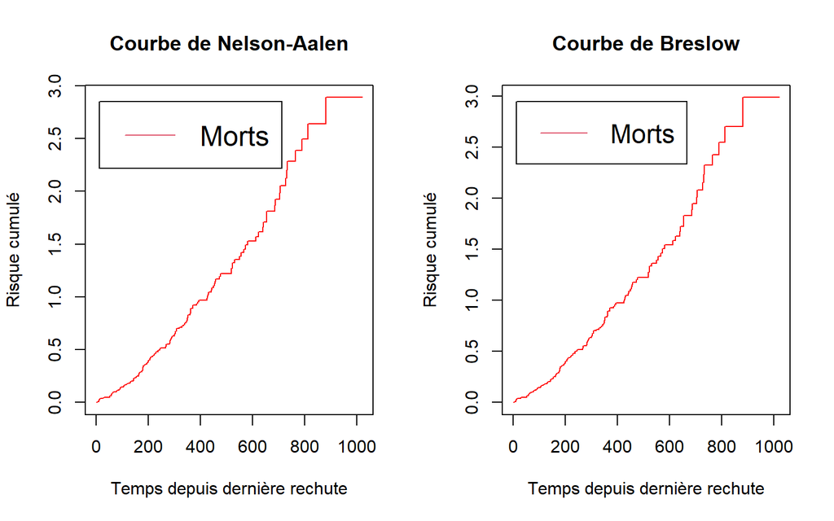

```r
par(mfrow=c(1, 2))

myNelsonAalen(survit_value = kpl_one)

plot(c(0,xval),c(0,eBreslow),type="s",col="red",xlab="Temps depuis dernière rechute",
     ylab="Risque cumulé", main= "Courbe de Breslow")
legend("topleft",c("Morts"), col=2, lty=c(1,1),
       cex=1.5, inset = 0.05 )
```

Le risque cumulé étant la probabilité de devenir malade (et ou de mourir) au cours d’une période fixée.

## Modèles Paramétriques

### a°) Test de conformité

Ici on doit tester si $T$ suit une loi de **Weibull**, **Exponentielle**, **Gamma**, … en prénant en compte le cas de censures.

La l’utilisation de la fonction **fitdistcens** nécéssite de connaître les types de censures (gauche et droite), mais les données lung ne donnent pas ces informations (le type de censure).

Ici on va donc tester en supposant qu’on a pas de censure dans nos données.

```r
library(fitdistrplus)

time_cens <- data.frame(left=c(cancer$time[cancer$status==1],rep(NA,102 )), right=cancer$time[cancer$status==2])

fitsf  <-  fitdist(cancer$time,"weibull")

summary(fitsf)
```

```
## Fitting of the distribution ' weibull ' by maximum likelihood
## Parameters :
##         estimate  Std. Error
## shape   1.467021  0.07568529
## scale 336.743311 15.98974355
## Loglikelihood:  -1509.627   AIC:  3023.254   BIC:  3030.113
## Correlation matrix:
##           shape     scale
## shape 1.0000000 0.3096148
## scale 0.3096148 1.0000000
```

### b°) Estimation de $\theta$ par MLE

Ici on suppose que nos données T proviennent d’une loi de Weibull comme indiqué dans la fiche de TP.

Donc on essaie d’estimer les paramètres $\theta = \begin{bmatrix} a \\ \lambda \end{bmatrix}$ de la loi de **Weibull** par la méthode de l’EMV à partir de la formule vue en cours et TD (cas de Censures).

```r
MLE <- function(a_lamda, ti_deltai){


  -sum(ti_delta[,2]*(log(a_lamda[1])
              -a_lamda[1]*log(a_lamda[2])
              +(a_lamda[1]-1)*log(ti_delta[,1]))-
         (ti_delta[,1]/a_lamda[2])^a_lamda[1])

}
```

```r
MLE <- function(a_lamda){
  -sum(o[,2]*(log(a_lamda[1])
              -a_lamda[1]*log(a_lamda[2])
              +(a_lamda[1]-1)*log(o[,1]))-
         (o[,1]/a_lamda[2])^a_lamda[1])

}

ti_deltai <- cbind(ti=cancer2$time ,
                   deltai= cancer2$status)
o <- ti_deltai

nlm(MLE, p=c(1,3), print.level = 1)
```

```
## iteration = 0
## Step:
## [1] 0 0
## Parameter:
## [1] 1 3
## Function Value
## [1] 23629.42
## Gradient:
## [1] 110449.587  -7601.548
##
## iteration = 35
## Parameter:
## [1]   1.401022 225.343324
## Function Value
## [1] 2397.039
## Gradient:
## [1]  9.542728e-05 -9.484694e-07
##
## Gradient relatif proche de zéro.
## L'itération courante est probablement la solution.
```

```
## $minimum
## [1] 2397.039
##
## $estimate
## [1]   1.401022 225.343324
##
## $gradient
## [1]  9.542728e-05 -9.484694e-07
##
## $code
## [1] 1
##
## $iterations
## [1] 35
```

Après convergence, on que $T$ suit **Weibull** de paramètre $\theta = \begin{bmatrix} 1.4 \\ 225.34 \end{bmatrix}$)

## Estimation du modèle en présence de covariables (Exercice 2)

### 1. Non parametrique :

Pour une distribution non parametrique, la courbe de Kaplan-Meier, Nelson Aalen et/ou Breslow nous permet d’estimer la ourbe de survie en présence/absence de covariables.

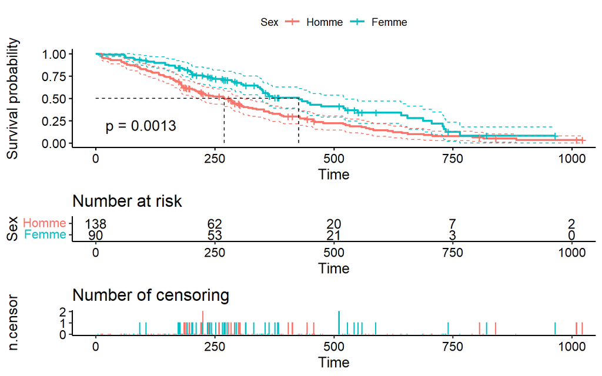

```r
surv_sex <- survfit(mort ~ sex, data = cancer2, conf.type = "plain")#"log-log")

#summary(surv_sex)

# Kaplan-Meir
ggsurvplot(surv_sex, data=cancer2, conf.int = TRUE, risk.table = TRUE, pval = TRUE,
           legend.title ="Sex",
           legend.labs =c("Homme", "Femme"),
           ncensor.plot = TRUE,      # plot the number of censored subjects at time t
          ncensor.plot.height = 0.25,
          conf.int.style = "step",  # customize style of confidence intervals
          surv.median.line = "hv")
```

En prénant en compte le facteur genre (sexe) dans l’analyse, on constate qu’en général les femmes (2) supportent plus ce cancer que les hommes (1), mais on voit que les deux sont rélativement proches vers les 760 jours environ.

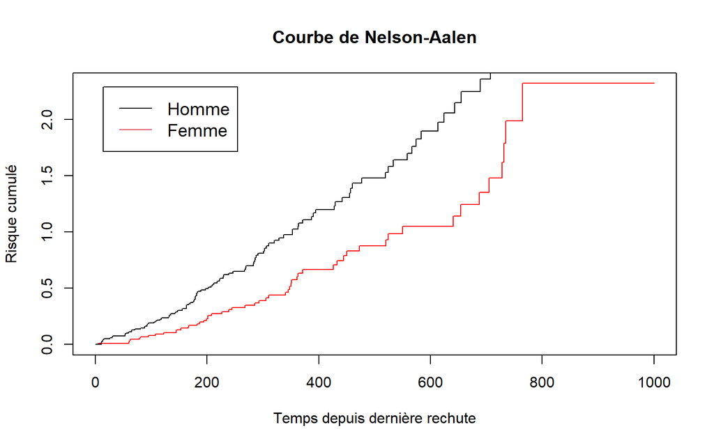

```r
## Nelson-Aalen

myNelsonAalen(survit_value = surv_sex, covariable = TRUE,
              legendes= c("Homme", "Femme"))
```

Ci-dessus, on remarque qu’en général, les hommes ont un risque plus élevé que les femmes. Par exemple au bout de t = 200 jours, les hommes ont environ 51% de risque de rechute tandis que les femmes ont seulement 30%.

### 2. Parametrique Conditionnelle :

#### Modèles GLM

```r
glm = glm(time~., data = cancer, family=gaussian)

summary(glm)
```

```
##
## Call:
## glm(formula = time ~ ., family = gaussian, data = cancer)
##
## Deviance Residuals:
##     Min       1Q   Median       3Q      Max
## -313.11  -139.27   -49.36    85.55   626.95
##
## Coefficients:
##              Estimate Std. Error t value Pr(>|t|)
## (Intercept) 470.72304  294.62153   1.598   0.1121
## inst          0.64033    2.03734   0.314   0.7537
## status      -39.89237   38.02028  -1.049   0.2957
## age           0.26167    1.93441   0.135   0.8926
## sex          48.37135   35.37907   1.367   0.1735
## ph.ecog     -84.20802   40.57442  -2.075   0.0396 *
## ph.karno     -3.30927    2.28338  -1.449   0.1493
## pat.karno     1.50409    1.31379   1.145   0.2540
## meal.cal      0.03538    0.04207   0.841   0.4016
## wt.loss       1.77206    1.26144   1.405   0.1621
## ---
## Signif. codes:  0 '***' 0.001 '**' 0.01 '*' 0.05 '.' 0.1 ' ' 1
##
## (Dispersion parameter for gaussian family taken to be 42133.3)
##
##     Null deviance: 7281302  on 166  degrees of freedom
## Residual deviance: 6614928  on 157  degrees of freedom
##   (61 observations deleted due to missingness)
## AIC: 2263.9
##
## Number of Fisher Scoring iterations: 2
```

## Modèle de Cox (Exercice 3)

```r
l.survreg.weibull <- survreg(mort ~ strata(sex), data=cancer2, dist='weibull')

l.survreg.weibull
```

```
## Call:
## survreg(formula = mort ~ strata(sex), data = cancer2, dist = "weibull")
##
## Coefficients:
## (Intercept)
##    6.062171
##
## Scale:
##     sex=1     sex=2
## 0.8167551 0.6533036
##
## Loglik(model)= -1152.5   Loglik(intercept only)= -1152.5
## n= 228
```

```r
#ggsurvplot(l.survreg.weibull, data=cancer2, conf.int = TRUE)
```

```r
l.survreg <- survreg(mort ~ sex + age, data=cancer2)
summary(l.survreg)
```

```
##
## Call:
## survreg(formula = mort ~ sex + age, data = cancer2)
##                Value Std. Error     z       p
## (Intercept)  6.27485    0.48137 13.04 < 2e-16
## sex          0.38209    0.12748  3.00  0.0027
## age         -0.01226    0.00696 -1.76  0.0781
## Log(scale)  -0.28230    0.06188 -4.56 5.1e-06
##
## Scale= 0.754
##
## Weibull distribution
## Loglik(model)= -1147.1   Loglik(intercept only)= -1153.9
##  Chisq= 13.59 on 2 degrees of freedom, p= 0.0011
## Number of Newton-Raphson Iterations: 5
## n= 228
```

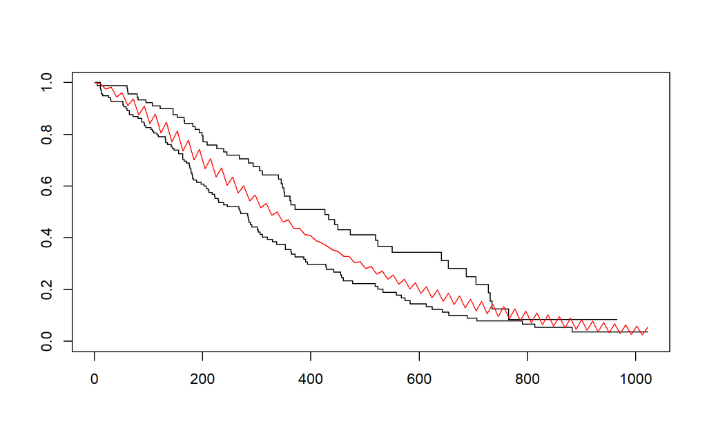

```r
plot(survfit(mort~strata(sex), data=cancer2))

curve(exp(-(exp(-l.survreg.weibull$coef[1]) * x)^(1/l.survreg.weibull$scale)),
        col="red", add=TRUE)
```

#### Cox avec une covariable le sexe

```r
cox.fit = coxph(mort~ sex, data = cancer2)

cox.fit
```

```
## Call:
## coxph(formula = mort ~ sex, data = cancer2)
##
##        coef exp(coef) se(coef)      z       p
## sex -0.5310    0.5880   0.1672 -3.176 0.00149
##
## Likelihood ratio test=10.63  on 1 df, p=0.001111
## n= 228, number of events= 165
```

```r
summary(cox.fit)
```

```
## Call:
## coxph(formula = mort ~ sex, data = cancer2)
##
##   n= 228, number of events= 165
##
##        coef exp(coef) se(coef)      z Pr(>|z|)
## sex -0.5310    0.5880   0.1672 -3.176  0.00149 **
## ---
## Signif. codes:  0 '***' 0.001 '**' 0.01 '*' 0.05 '.' 0.1 ' ' 1
##
##     exp(coef) exp(-coef) lower .95 upper .95
## sex     0.588      1.701    0.4237     0.816
##
## Concordance= 0.579  (se = 0.021 )
## Likelihood ratio test= 10.63  on 1 df,   p=0.001
## Wald test            = 10.09  on 1 df,   p=0.001
## Score (logrank) test = 10.33  on 1 df,   p=0.001
```

#### Cox avec plusieurs covariables (sexe, age, wt.loss, …)

```r
cox.fit2 = coxph(Surv(time, status)~ sex + age + wt.loss + ph.ecog + ph.karno + pat.karno + meal.cal, data = cancer2)

summary(cox.fit2)
```

```
## Call:
## coxph(formula = Surv(time, status) ~ sex + age + wt.loss + ph.ecog +
##     ph.karno + pat.karno + meal.cal, data = cancer2)
##
##   n= 168, number of events= 121
##    (60 observations deleted due to missingness)
##
##                 coef  exp(coef)   se(coef)      z Pr(>|z|)
## sex       -5.509e-01  5.765e-01  2.008e-01 -2.743  0.00609 **
## age        1.065e-02  1.011e+00  1.161e-02  0.917  0.35906
## wt.loss   -1.433e-02  9.858e-01  7.771e-03 -1.844  0.06518 .
## ph.ecog    7.342e-01  2.084e+00  2.233e-01  3.288  0.00101 **
## ph.karno   2.246e-02  1.023e+00  1.124e-02  1.998  0.04574 *
## pat.karno -1.242e-02  9.877e-01  8.054e-03 -1.542  0.12316
## meal.cal   3.329e-05  1.000e+00  2.595e-04  0.128  0.89791
## ---
## Signif. codes:  0 '***' 0.001 '**' 0.01 '*' 0.05 '.' 0.1 ' ' 1
##
##           exp(coef) exp(-coef) lower .95 upper .95
## sex          0.5765     1.7347    0.3889    0.8545
## age          1.0107     0.9894    0.9880    1.0340
## wt.loss      0.9858     1.0144    0.9709    1.0009
## ph.ecog      2.0838     0.4799    1.3452    3.2277
## ph.karno     1.0227     0.9778    1.0004    1.0455
## pat.karno    0.9877     1.0125    0.9722    1.0034
## meal.cal     1.0000     1.0000    0.9995    1.0005
##
## Concordance= 0.651  (se = 0.029 )
## Likelihood ratio test= 28.33  on 7 df,   p=2e-04
## Wald test            = 27.58  on 7 df,   p=3e-04
## Score (logrank) test = 28.41  on 7 df,   p=2e-04
```

```r
cox.fit2 = coxph(Surv(time, status)~ sex + age + wt.loss + ph.ecog + ph.karno + pat.karno, data = cancer2)

summary(cox.fit2)
```

```
## Call:
## coxph(formula = Surv(time, status) ~ sex + age + wt.loss + ph.ecog +
##     ph.karno + pat.karno, data = cancer2)
##
##   n= 210, number of events= 148
##    (18 observations deleted due to missingness)
##
##                coef exp(coef)  se(coef)      z Pr(>|z|)
## sex       -0.625167  0.535172  0.178703 -3.498 0.000468 ***
## age        0.013058  1.013144  0.009866  1.324 0.185639
## wt.loss   -0.013243  0.986844  0.007009 -1.889 0.058836 .
## ph.ecog    0.675227  1.964479  0.198735  3.398 0.000680 ***
## ph.karno   0.020116  1.020320  0.010178  1.976 0.048111 *
## pat.karno -0.014743  0.985365  0.007300 -2.019 0.043440 *
## ---
## Signif. codes:  0 '***' 0.001 '**' 0.01 '*' 0.05 '.' 0.1 ' ' 1
##
##           exp(coef) exp(-coef) lower .95 upper .95
## sex          0.5352     1.8686    0.3770    0.7596
## age          1.0131     0.9870    0.9937    1.0329
## wt.loss      0.9868     1.0133    0.9734    1.0005
## ph.ecog      1.9645     0.5090    1.3307    2.9001
## ph.karno     1.0203     0.9801    1.0002    1.0409
## pat.karno    0.9854     1.0149    0.9714    0.9996
##
## Concordance= 0.656  (se = 0.025 )
## Likelihood ratio test= 37.2  on 6 df,   p=2e-06
## Wald test            = 36.49  on 6 df,   p=2e-06
## Score (logrank) test = 37.59  on 6 df,   p=1e-06
```

```r
cox.fit2 = coxph(Surv(time, status)~ sex + wt.loss + ph.ecog + ph.karno + pat.karno, data = cancer2)

summary(cox.fit2)
```

```
## Call:
## coxph(formula = Surv(time, status) ~ sex + wt.loss + ph.ecog +
##     ph.karno + pat.karno, data = cancer2)
##
##   n= 210, number of events= 148
##    (18 observations deleted due to missingness)
##
##                coef exp(coef)  se(coef)      z Pr(>|z|)
## sex       -0.614915  0.540687  0.177886 -3.457 0.000547 ***
## wt.loss   -0.012914  0.987169  0.006844 -1.887 0.059162 .
## ph.ecog    0.682441  1.978702  0.201278  3.391 0.000698 ***
## ph.karno   0.018887  1.019066  0.010267  1.840 0.065838 .
## pat.karno -0.015255  0.984861  0.007306 -2.088 0.036797 *
## ---
## Signif. codes:  0 '***' 0.001 '**' 0.01 '*' 0.05 '.' 0.1 ' ' 1
##
##           exp(coef) exp(-coef) lower .95 upper .95
## sex          0.5407     1.8495    0.3815    0.7662
## wt.loss      0.9872     1.0130    0.9740    1.0005
## ph.ecog      1.9787     0.5054    1.3337    2.9357
## ph.karno     1.0191     0.9813    0.9988    1.0398
## pat.karno    0.9849     1.0154    0.9709    0.9991
##
## Concordance= 0.659  (se = 0.026 )
## Likelihood ratio test= 35.41  on 5 df,   p=1e-06
## Wald test            = 35.47  on 5 df,   p=1e-06
## Score (logrank) test = 36.33  on 5 df,   p=8e-07
```

```r
cox.fit_f = coxph(Surv(time, status) ~ sex  + ph.ecog , data = cancer2)

summary(cox.fit2)
```

```
## Call:
## coxph(formula = Surv(time, status) ~ sex + wt.loss + ph.ecog +
##     ph.karno + pat.karno, data = cancer2)
##
##   n= 210, number of events= 148
##    (18 observations deleted due to missingness)
##
##                coef exp(coef)  se(coef)      z Pr(>|z|)
## sex       -0.614915  0.540687  0.177886 -3.457 0.000547 ***
## wt.loss   -0.012914  0.987169  0.006844 -1.887 0.059162 .
## ph.ecog    0.682441  1.978702  0.201278  3.391 0.000698 ***
## ph.karno   0.018887  1.019066  0.010267  1.840 0.065838 .
## pat.karno -0.015255  0.984861  0.007306 -2.088 0.036797 *
## ---
## Signif. codes:  0 '***' 0.001 '**' 0.01 '*' 0.05 '.' 0.1 ' ' 1
##
##           exp(coef) exp(-coef) lower .95 upper .95
## sex          0.5407     1.8495    0.3815    0.7662
## wt.loss      0.9872     1.0130    0.9740    1.0005
## ph.ecog      1.9787     0.5054    1.3337    2.9357
## ph.karno     1.0191     0.9813    0.9988    1.0398
## pat.karno    0.9849     1.0154    0.9709    0.9991
##
## Concordance= 0.659  (se = 0.026 )
## Likelihood ratio test= 35.41  on 5 df,   p=1e-06
## Wald test            = 35.47  on 5 df,   p=1e-06
## Score (logrank) test = 36.33  on 5 df,   p=8e-07
```

## Diagnostic (Exercice 4)

a.°) Diagnostic sur le modèle de Weibull

```r
library(SurvRegCensCov)

ConvertWeibull(l.survreg.weibull)$vars
```

```
##            Estimate           SE
## sex=1  0.0005977951 0.0003477260
## sex=2  0.0000933406 0.0000678785
## sex=1  1.2243572393 0.0972869204
## sex=2  1.5306819896 0.1216273585
##                  NA           NA
##       -9.2792554024 0.7226445301
##        0.0005977951           NA
##        0.0000933406 0.7272129900
```

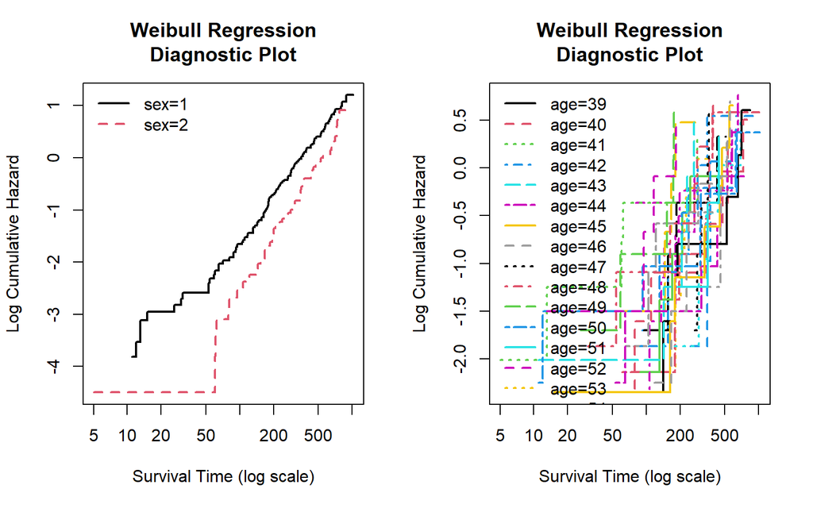

```r
par(mfrow=c(1, 2))
WeibullDiag(mort~sex, data=cancer2)

WeibullDiag(mort~age, data=cancer2)
```

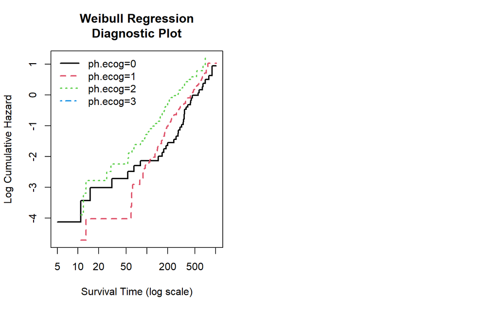

```r
WeibullDiag(mort~ph.ecog, data=cancer2)
```

2. °) Diagnostic sur le modèle Cox

#### Verification de l’hypothèse HP

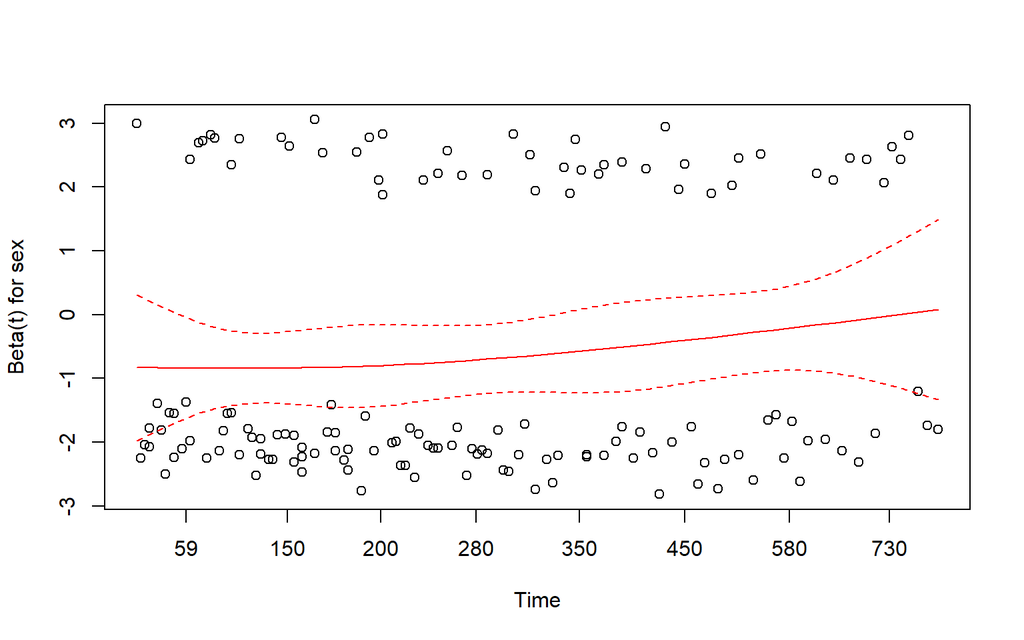

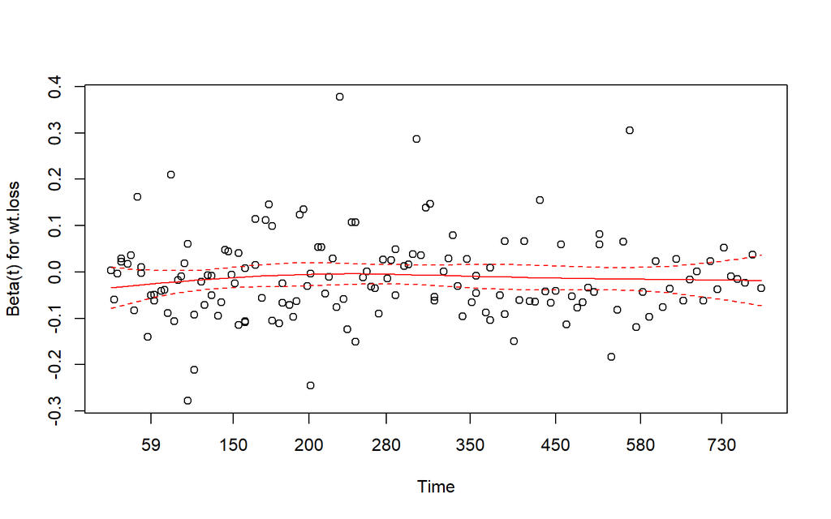

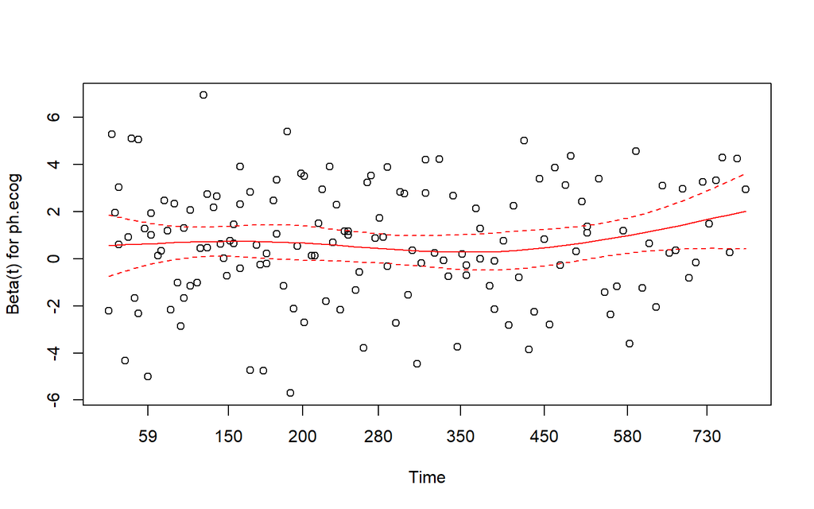

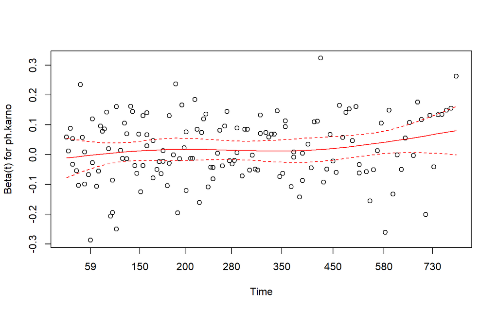

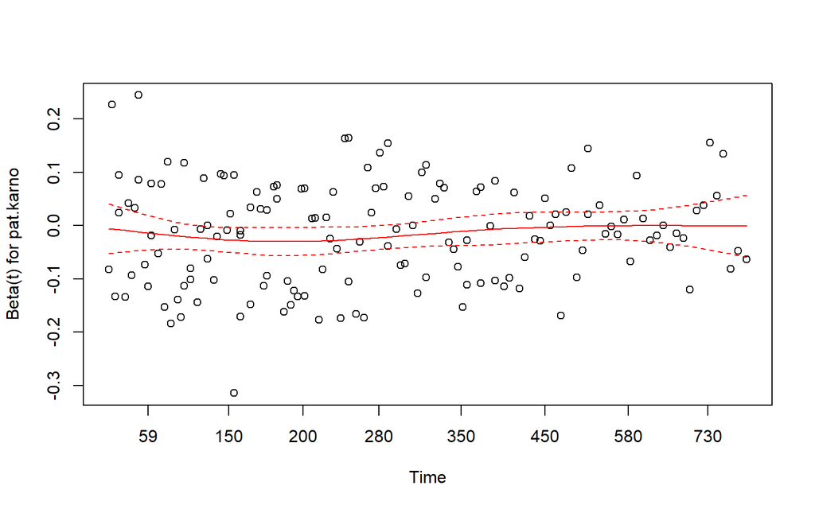

```r
#test de Schoenfeld
res.c=cox.zph(cox.fit2)
#Test graphique des r?sidus de Schoenfeld : il doit y avoir absence de
#tendance temporelle.
plot(res.c, pch=19, col="red") ## si le plot est une droite horizontale --> H0 vrai, On rejette H0 sinon
```

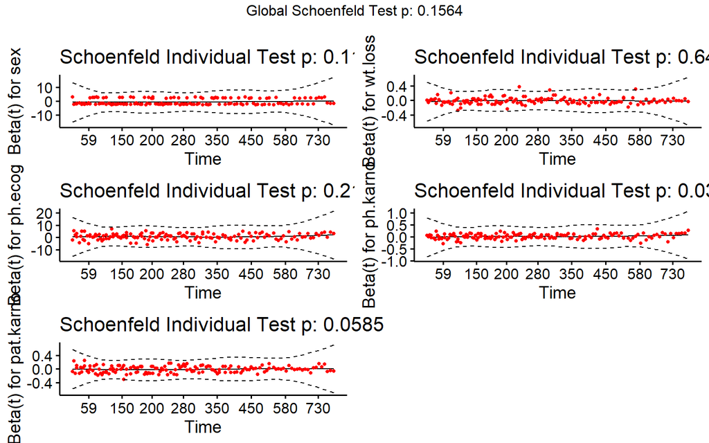

```r
library("survival")
library(survminer)
ggcoxzph(res.c)
```

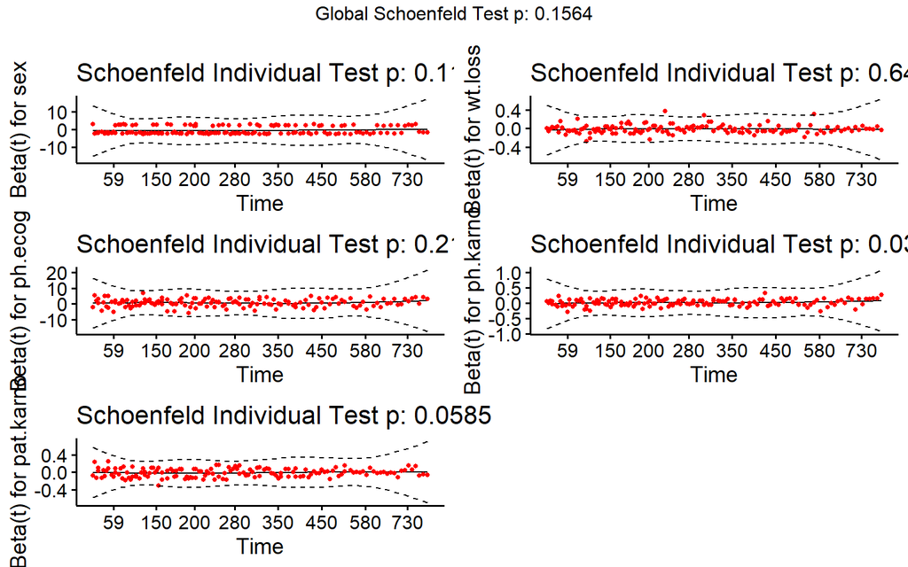

```r
ggcoxzph(cox.zph(cox.fit2),type="deviance")
```

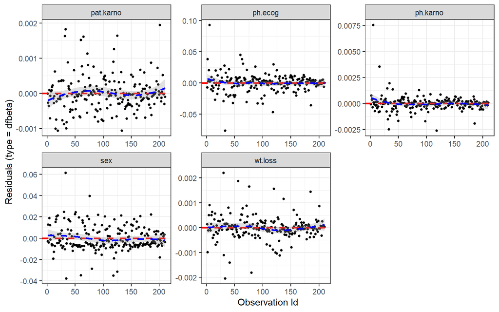

```r
ggcoxdiagnostics(cox.fit2, type = "dfbeta",
                 linear.predictions = FALSE, ggtheme = theme_bw())
```

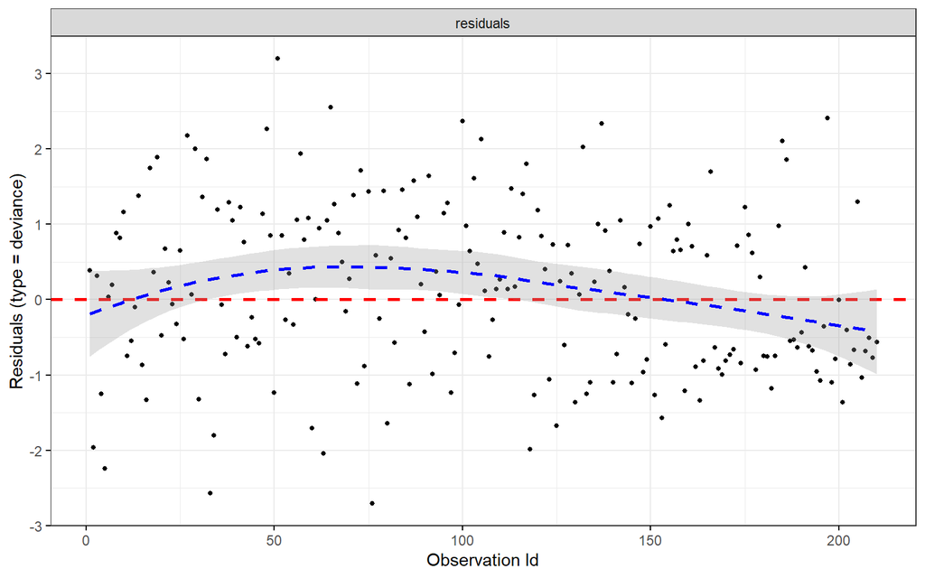

```r
ggcoxdiagnostics(cox.fit2, type = "deviance",
                 linear.predictions = FALSE, ggtheme = theme_bw())
```

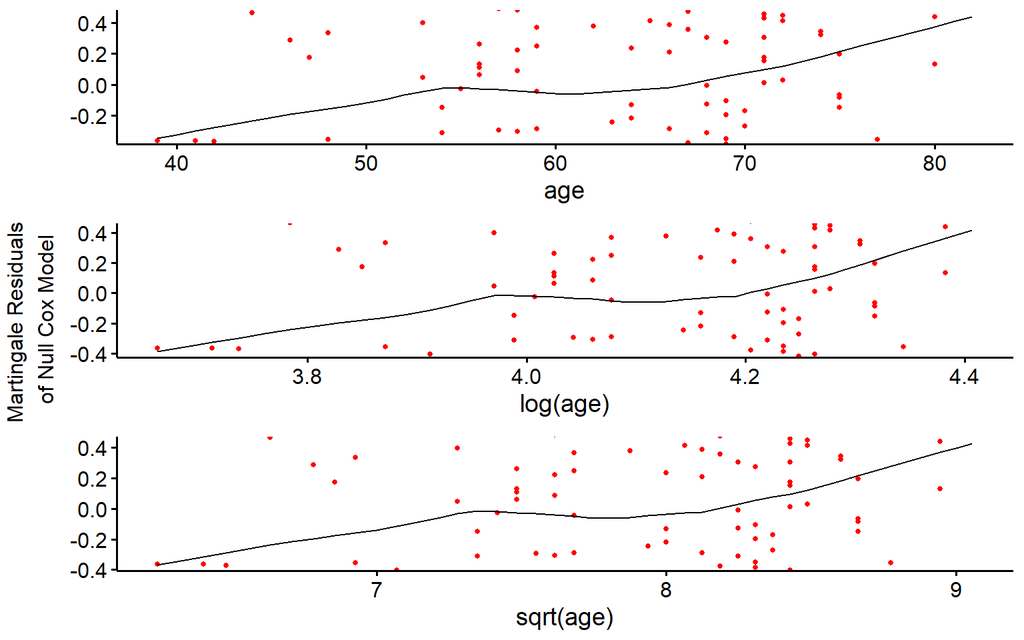

```r
ggcoxfunctional(Surv(time, status) ~ age + log(age) + sqrt(age), data = cancer)
```